# Strategy, Leadership, and Narratives: Data Viz for Policy Change

Jared E. Knowles

May 7, 2014

# What do you want to say?

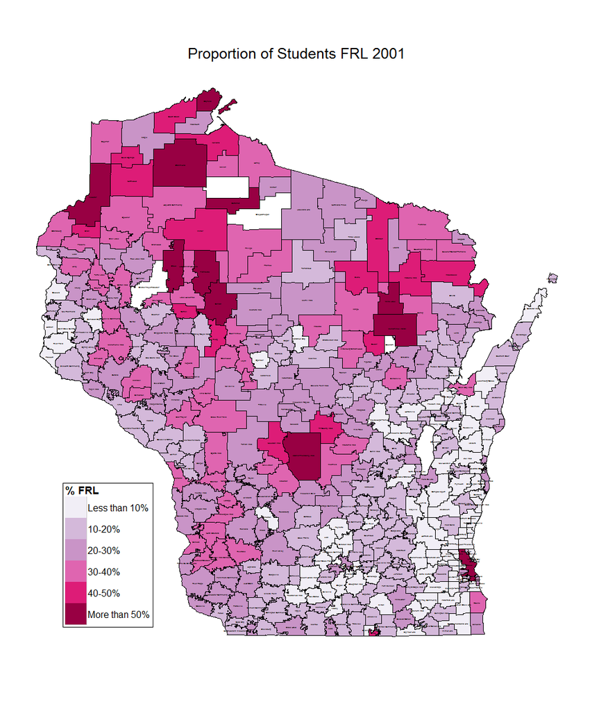

# Model fit

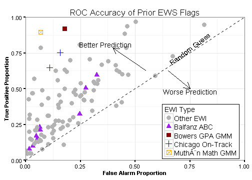

# Of Metrics and Dashboards

Widgets provide limited utility.

[figure not shown]

# The Struggle

[figure not shown]

# The First Directive

> Know thy data, but know thy audience better.
- What is their question?
- What is their timeframe?
- What are their constraints?
- What is their capacity?

# Yabbut - too much data

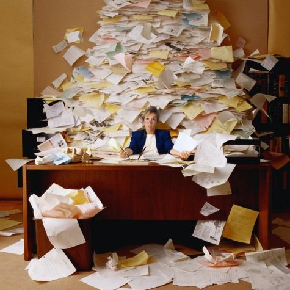

# Yabbut - too many priorities

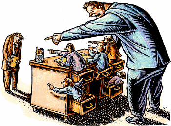

# The Way Out

1. Identify your goals
2. Explore your data and focus
3. Focus even narrower
4. Find the context
5. Put it together

# Identify your goals

What is the goal of this graphic?

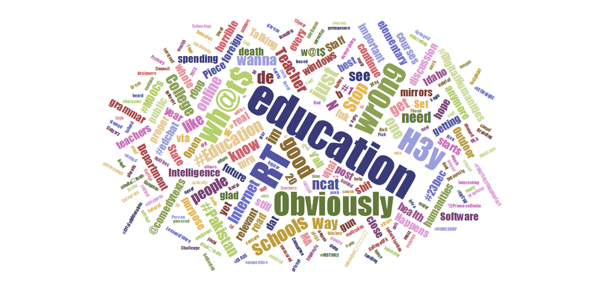

# What did we learn?

- The words `obviously` and `education` were used a lot
- Some other words were frequent too
- **what value have we provided?**

# Goals need not mean complex graphics

[figure not shown]

# What do we learn?

- More power = faster times
- Clear outliers are identified to enable discussion
- Reference lines are provided to give audience orientation
- A smoother is applied to show the general trend

# Quote

How you turn dimensions in the data into visual cues for your audience is everything.

# Balance is hard

Term: Raw data - Plot the points as is - Pros: easy to explain and interpret - Cons: does not scale well, insights not obvious

Term: Summarize - Summarize the data and plot summaries - Pros: Meaningful summaries are efficient - Cons: More complex, summaries may skew important features

Term: Model - Model the data and show simulations or projections - Pros: Forces analysis to answer questions - Cons: Complex, difficult to convey results

# Talk Outline

- Problem Statement
- Lots of data, lots of demand
- Limited time, space, and opportunity
- Role of Leadership
- Be strategic in what you present
- Lead your audience – analysis, not data
- Tools
- Context
- Counterfactuals
- Simulation
- Practical

# Slide with R Code and Output | A subtitle

```r
summary(cars)
```

```
     speed           dist
 Min.   : 4.0   Min.   :  2
 1st Qu.:12.0   1st Qu.: 26
 Median :15.0   Median : 36
 Mean   :15.4   Mean   : 43
 3rd Qu.:19.0   3rd Qu.: 56
 Max.   :25.0   Max.   :120
```

# Slide with Plot

[figure not shown]

# A Simple Table

Demonstration of simple table syntax.

[output not shown]

# A multiline table

[output not shown]

# R Markdown

Opinions about data visualization are everywhere and quick search online reveals thousands of resources to learn how to draw bar graphs and when a scatter plot might be effective. While getting the technical details right is important, it is merely the a necessary, but not sufficient, condition for driving change. In order to effectively use data in a decision making context, analysts must focus on knowing their audience, knowing the decision space, and leading their audience toward constructive engagement with the data. Using examples from senior leadership discussions at the Wisconsin Department of Public Instruction, this talk will explore how to build capacity in an audience and empower them to make decisions informed by analytics. A particular focus will be taken on the deliberate design choices an analyst must confront in order construct visualizations that are accessible and invite discussion. This includes strategies such as simulation, counterfactual modeling, and selection of context cues to bring the data into a familiar frame for the audience. The session will conclude with a brief discussion of practical advice on technologies, formats, and presentation techniques for different audience types.

# Asset

```r
library(png)
library(grid)
img <- readPNG("assets/ewsLITplot.png")
grid.raster(img)
```

[figure not shown]